# Case Study : BikeTrips (Last 12 months data)

Jyotisman

6/12/2021

## Import and Load libraries

Let’s start by installing the tidyverse package. We also have to load the lubridate package separately as it does not automatically gets loaded with tidyverse.

```
##
##  /var/folders/br/6jvgf_pn0x50sx8zrhxrvh4c0000gn/T//RtmpOncN2I/downloaded_packages
```

## Collect Data

The business task entails exploring how different customer types are using Cyclistic bikes and for that we will use Cyclistic’s historical trip data to analyze and identify trends. We will use last 12 months of data starting from the May of 2020 to April of 2021.

The relevant data was obtained from [here](https://divvy-tripdata.s3.amazonaws.com/index.html) and stored locally. It has been made available by Motivate International Inc. under this [license](https://www.divvybikes.com/data-license-agreement).

```r
files <- list.files(path = "/Users/jyotisman/Library/Mobile Documents/com~apple~CloudDocs/Google_Data_analytics/Case_study/bike_trips_data/2021+2020", pattern = "*.csv", full.names = T)
tbl <- lapply(files, read_csv)
```

## Data Cleaning

```r
tbl <-  lapply(tbl, function(x){mutate(x, start_station_id = as.character(start_station_id),
                   end_station_id = as.character(end_station_id))})
all_trips <- bind_rows(tbl)
head(all_trips)
```

```
## # A tibble: 6 x 13
##   ride_id rideable_type started_at          ended_at            start_station_n…
##   <chr>   <chr>         <dttm>              <dttm>              <chr>
## 1 02668A… docked_bike   2020-05-27 10:03:52 2020-05-27 10:16:49 Franklin St & J…
## 2 7A50CC… docked_bike   2020-05-25 10:47:11 2020-05-25 11:05:40 Clark St & Wrig…
## 3 2FFCDF… docked_bike   2020-05-02 14:11:03 2020-05-02 15:48:21 Kedzie Ave & Mi…
## 4 58991C… docked_bike   2020-05-02 16:25:36 2020-05-02 16:39:28 Clarendon Ave &…
## 5 A79651… docked_bike   2020-05-29 12:49:54 2020-05-29 13:27:11 Hermitage Ave &…
## 6 1466C5… docked_bike   2020-05-29 13:27:24 2020-05-29 14:14:45 Halsted St & Ar…
## # … with 8 more variables: start_station_id <chr>, end_station_name <chr>,
## #   end_station_id <chr>, start_lat <dbl>, start_lng <dbl>, end_lat <dbl>,
## #   end_lng <dbl>, member_casual <chr>
```

Let’s check the column name again.

```r
colnames(all_trips)
```

```
##  [1] "ride_id"            "rideable_type"      "started_at"
##  [4] "ended_at"           "start_station_name" "start_station_id"
##  [7] "end_station_name"   "end_station_id"     "start_lat"
## [10] "start_lng"          "end_lat"            "end_lng"
## [13] "member_casual"
```

And also the structure of the dataset —–

```r
str(all_trips)
```

```
## spec_tbl_df [3,742,202 × 13] (S3: spec_tbl_df/tbl_df/tbl/data.frame)
##  $ ride_id           : chr [1:3742202] "02668AD35674B983" "7A50CCAF1EDDB28F" "2FFCDFDB91FE9A52" "58991CF1DB75BA84" ...
##  $ rideable_type     : chr [1:3742202] "docked_bike" "docked_bike" "docked_bike" "docked_bike" ...
##  $ started_at        : POSIXct[1:3742202], format: "2020-05-27 10:03:52" "2020-05-25 10:47:11" ...
##  $ ended_at          : POSIXct[1:3742202], format: "2020-05-27 10:16:49" "2020-05-25 11:05:40" ...
##  $ start_station_name: chr [1:3742202] "Franklin St & Jackson Blvd" "Clark St & Wrightwood Ave" "Kedzie Ave & Milwaukee Ave" "Clarendon Ave & Leland Ave" ...
##  $ start_station_id  : chr [1:3742202] "36" "340" "260" "251" ...
##  $ end_station_name  : chr [1:3742202] "Wabash Ave & Grand Ave" "Clark St & Leland Ave" "Kedzie Ave & Milwaukee Ave" "Lake Shore Dr & Wellington Ave" ...
##  $ end_station_id    : chr [1:3742202] "199" "326" "260" "157" ...
##  $ start_lat         : num [1:3742202] 41.9 41.9 41.9 42 41.9 ...
##  $ start_lng         : num [1:3742202] -87.6 -87.6 -87.7 -87.7 -87.7 ...
##  $ end_lat           : num [1:3742202] 41.9 42 41.9 41.9 41.8 ...
##  $ end_lng           : num [1:3742202] -87.6 -87.7 -87.7 -87.6 -87.6 ...
##  $ member_casual     : chr [1:3742202] "member" "casual" "casual" "casual" ...
##  - attr(*, "spec")=
##   .. cols(
##   ..   ride_id = col_character(),
##   ..   rideable_type = col_character(),
##   ..   started_at = col_datetime(format = ""),
##   ..   ended_at = col_datetime(format = ""),
##   ..   start_station_name = col_character(),
##   ..   start_station_id = col_double(),
##   ..   end_station_name = col_character(),
##   ..   end_station_id = col_double(),
##   ..   start_lat = col_double(),
##   ..   start_lng = col_double(),
##   ..   end_lat = col_double(),
##   ..   end_lng = col_double(),
##   ..   member_casual = col_character()
##   .. )
```

We do not need all the columns for example the latitude and longitude information. Let’s remove them.

```r
all_trips <- all_trips %>%
  select(-c(start_lat, start_lng, end_lat, end_lng))
```

```r
nrow(all_trips)
```

```
## [1] 3742202
```

```r
str(all_trips)
```

```
## tibble [3,742,202 × 9] (S3: tbl_df/tbl/data.frame)
##  $ ride_id           : chr [1:3742202] "02668AD35674B983" "7A50CCAF1EDDB28F" "2FFCDFDB91FE9A52" "58991CF1DB75BA84" ...
##  $ rideable_type     : chr [1:3742202] "docked_bike" "docked_bike" "docked_bike" "docked_bike" ...
##  $ started_at        : POSIXct[1:3742202], format: "2020-05-27 10:03:52" "2020-05-25 10:47:11" ...
##  $ ended_at          : POSIXct[1:3742202], format: "2020-05-27 10:16:49" "2020-05-25 11:05:40" ...
##  $ start_station_name: chr [1:3742202] "Franklin St & Jackson Blvd" "Clark St & Wrightwood Ave" "Kedzie Ave & Milwaukee Ave" "Clarendon Ave & Leland Ave" ...
##  $ start_station_id  : chr [1:3742202] "36" "340" "260" "251" ...
##  $ end_station_name  : chr [1:3742202] "Wabash Ave & Grand Ave" "Clark St & Leland Ave" "Kedzie Ave & Milwaukee Ave" "Lake Shore Dr & Wellington Ave" ...
##  $ end_station_id    : chr [1:3742202] "199" "326" "260" "157" ...
##  $ member_casual     : chr [1:3742202] "member" "casual" "casual" "casual" ...
```

summary() can be used to look at basic summary statistics of each column. Let’s do that next.

```r
summary(all_trips)
```

```
##    ride_id          rideable_type        started_at
##  Length:3742202     Length:3742202     Min.   :2020-05-01 00:02:07
##  Class :character   Class :character   1st Qu.:2020-07-23 19:27:14
##  Mode  :character   Mode  :character   Median :2020-09-09 15:51:13
##                                        Mean   :2020-10-03 00:35:53
##                                        3rd Qu.:2020-11-15 17:49:27
##                                        Max.   :2021-04-30 23:59:53
##     ended_at                   start_station_name start_station_id
##  Min.   :2020-05-01 00:13:03   Length:3742202     Length:3742202
##  1st Qu.:2020-07-23 19:59:58   Class :character   Class :character
##  Median :2020-09-09 16:08:31   Mode  :character   Mode  :character
##  Mean   :2020-10-03 01:00:21
##  3rd Qu.:2020-11-15 18:05:29
##  Max.   :2021-05-05 22:14:39
##  end_station_name   end_station_id     member_casual
##  Length:3742202     Length:3742202     Length:3742202
##  Class :character   Class :character   Class :character
##  Mode  :character   Mode  :character   Mode  :character
##
##
##
```

Let’s view the null values in the data frame that shows up in the summary.

```r
all_trips[!complete.cases(all_trips),]
```

```
## # A tibble: 233,981 x 9
##    ride_id          rideable_type started_at          ended_at
##    <chr>            <chr>         <dttm>              <dttm>
##  1 08E0F78E1CFD68E3 docked_bike   2020-05-26 18:56:32 2020-05-27 04:40:44
##  2 A48456EF7719931B docked_bike   2020-05-18 16:22:00 2020-05-18 16:43:28
##  3 83FAF392AA066C64 docked_bike   2020-05-24 13:46:52 2020-05-24 14:16:41
##  4 65C257A3DEE7752A docked_bike   2020-05-25 17:05:23 2020-05-25 18:04:47
##  5 63A4FEDCF0722A16 docked_bike   2020-05-16 14:52:10 2020-05-16 14:52:10
##  6 2BC442F8F9A11D86 docked_bike   2020-05-16 11:43:48 2020-05-16 12:07:08
##  7 141FFEEAC0C20A24 docked_bike   2020-05-28 22:05:30 2020-05-29 23:05:21
##  8 D9907ABA20AB6B5D docked_bike   2020-05-27 17:57:57 2020-05-28 18:57:49
##  9 F8BAEDD3220C92ED docked_bike   2020-05-27 13:01:24 2020-05-27 13:29:07
## 10 68F7F0DE8999CD9C docked_bike   2020-05-21 21:55:38 2020-05-22 07:45:15
## # … with 233,971 more rows, and 5 more variables: start_station_name <chr>,
## #   start_station_id <chr>, end_station_name <chr>, end_station_id <chr>,
## #   member_casual <chr>
```

Seems like there are around **200,000** observations with null values in at least one column. Let’s see if any of the columns we will be using are part of these.

```r
all_trips[!complete.cases(all_trips$started_at),]
```

```
## # A tibble: 0 x 9
## # … with 9 variables: ride_id <chr>, rideable_type <chr>, started_at <dttm>,
## #   ended_at <dttm>, start_station_name <chr>, start_station_id <chr>,
## #   end_station_name <chr>, end_station_id <chr>, member_casual <chr>
```

```r
all_trips[!complete.cases(all_trips$ended_at),]
```

```
## # A tibble: 0 x 9
## # … with 9 variables: ride_id <chr>, rideable_type <chr>, started_at <dttm>,
## #   ended_at <dttm>, start_station_name <chr>, start_station_id <chr>,
## #   end_station_name <chr>, end_station_id <chr>, member_casual <chr>
```

```r
all_trips[!complete.cases(all_trips$member_casual),]
```

```
## # A tibble: 0 x 9
## # … with 9 variables: ride_id <chr>, rideable_type <chr>, started_at <dttm>,
## #   ended_at <dttm>, start_station_name <chr>, start_station_id <chr>,
## #   end_station_name <chr>, end_station_id <chr>, member_casual <chr>
```

```r
all_trips[!(complete.cases(all_trips$end_station_id) | complete.cases(all_trips$end_station_name)),]
```

```
## # A tibble: 171,317 x 9
##    ride_id          rideable_type started_at          ended_at
##    <chr>            <chr>         <dttm>              <dttm>
##  1 08E0F78E1CFD68E3 docked_bike   2020-05-26 18:56:32 2020-05-27 04:40:44
##  2 A48456EF7719931B docked_bike   2020-05-18 16:22:00 2020-05-18 16:43:28
##  3 83FAF392AA066C64 docked_bike   2020-05-24 13:46:52 2020-05-24 14:16:41
##  4 65C257A3DEE7752A docked_bike   2020-05-25 17:05:23 2020-05-25 18:04:47
##  5 63A4FEDCF0722A16 docked_bike   2020-05-16 14:52:10 2020-05-16 14:52:10
##  6 2BC442F8F9A11D86 docked_bike   2020-05-16 11:43:48 2020-05-16 12:07:08
##  7 141FFEEAC0C20A24 docked_bike   2020-05-28 22:05:30 2020-05-29 23:05:21
##  8 D9907ABA20AB6B5D docked_bike   2020-05-27 17:57:57 2020-05-28 18:57:49
##  9 F8BAEDD3220C92ED docked_bike   2020-05-27 13:01:24 2020-05-27 13:29:07
## 10 68F7F0DE8999CD9C docked_bike   2020-05-21 21:55:38 2020-05-22 07:45:15
## # … with 171,307 more rows, and 5 more variables: start_station_name <chr>,
## #   start_station_id <chr>, end_station_name <chr>, end_station_id <chr>,
## #   member_casual <chr>
```

```r
all_trips[!(complete.cases(all_trips$start_station_id) | complete.cases(all_trips$start_station_name)),]
```

```
## # A tibble: 148,231 x 9
##    ride_id          rideable_type started_at          ended_at
##    <chr>            <chr>         <dttm>              <dttm>
##  1 60742256DFFFCA29 electric_bike 2020-07-31 08:30:34 2020-07-31 08:57:54
##  2 EBBD4FE9C8A95116 electric_bike 2020-07-29 19:02:25 2020-07-29 19:22:40
##  3 976336C6499A7189 electric_bike 2020-07-30 22:02:45 2020-07-30 22:17:54
##  4 EC549CDABDE45F98 electric_bike 2020-07-31 15:54:41 2020-07-31 16:00:35
##  5 70F53BFE303499AC electric_bike 2020-07-31 16:08:26 2020-07-31 16:15:29
##  6 11814668BAB6FCA3 electric_bike 2020-07-31 12:56:53 2020-07-31 13:13:27
##  7 D66AC7ACF66F8FF6 electric_bike 2020-07-30 08:32:14 2020-07-30 08:40:04
##  8 5196A992F09481DB electric_bike 2020-07-30 17:25:18 2020-07-30 17:25:35
##  9 2DB97E499E497D3D electric_bike 2020-07-30 17:28:20 2020-07-30 17:44:40
## 10 3C5018A592AB147C electric_bike 2020-07-31 18:40:31 2020-07-31 18:48:56
## # … with 148,221 more rows, and 5 more variables: start_station_name <chr>,
## #   start_station_id <chr>, end_station_name <chr>, end_station_id <chr>,
## #   member_casual <chr>
```

Seems like its the station ids (and names) that are missing which we won’t be using further in our analysis. So we don’t have to worry about the null values at least for the time being.

Next, let’s find out the unique values in the column member_casual. As mentioned in the business task, we should have two - **member** and **casual**.

```r
unique(all_trips$member_casual)
```

```
## [1] "member" "casual"
```

Since we are interested in trends over months, days or days of the week, its good to create separate columns for each of them.

```r
all_trips$date <- as.Date(all_trips$started_at) #The default format is yyyy-mm-dd
all_trips$month <- format(as.Date(all_trips$date), "%m")
all_trips$day <- format(as.Date(all_trips$date), "%d")
all_trips$year <- format(as.Date(all_trips$date), "%Y")
all_trips$day_of_week <- format(as.Date(all_trips$date), "%A")
all_trips$hour_of_day <- format(all_trips$started_at, "%H")
```

```r
head(all_trips)
```

```
## # A tibble: 6 x 15
##   ride_id rideable_type started_at          ended_at            start_station_n…
##   <chr>   <chr>         <dttm>              <dttm>              <chr>
## 1 02668A… docked_bike   2020-05-27 10:03:52 2020-05-27 10:16:49 Franklin St & J…
## 2 7A50CC… docked_bike   2020-05-25 10:47:11 2020-05-25 11:05:40 Clark St & Wrig…
## 3 2FFCDF… docked_bike   2020-05-02 14:11:03 2020-05-02 15:48:21 Kedzie Ave & Mi…
## 4 58991C… docked_bike   2020-05-02 16:25:36 2020-05-02 16:39:28 Clarendon Ave &…
## 5 A79651… docked_bike   2020-05-29 12:49:54 2020-05-29 13:27:11 Hermitage Ave &…
## 6 1466C5… docked_bike   2020-05-29 13:27:24 2020-05-29 14:14:45 Halsted St & Ar…
## # … with 10 more variables: start_station_id <chr>, end_station_name <chr>,
## #   end_station_id <chr>, member_casual <chr>, date <date>, month <chr>,
## #   day <chr>, year <chr>, day_of_week <chr>, hour_of_day <chr>
```

Now, we will create a column - **ride_length**, to measure the trip duration of each ride.

```r
all_trips$ride_length <- as.numeric(difftime(all_trips$ended_at,all_trips$started_at))
```

Make sure it is numeric.

```r
is.numeric(all_trips$ride_length)
```

```
## [1] TRUE
```

Now we are going to remove data that correspond to the ride_length being negative as its un-physical. Let’s store this in a new data frame - **all_trips_v2** as we will removing a portion of the original data.

```r
all_trips_v2 <- all_trips[!all_trips$ride_length<0,]
```

## Descriptive Analysis

Let’s find some general statistical descriptions of the **ride_length** variable.

```r
summary(all_trips_v2$ride_length)
```

```
##    Min. 1st Qu.  Median    Mean 3rd Qu.    Max.
##       0     470     861    1646    1584 3257001
```

First, let’s compare the summary statistics by rider types.

```r
all_trips_v2 %>%
  group_by(member_casual) %>%
  summarise(mean_rl = mean(ride_length), median_rl = median(ride_length), max_rl = max(ride_length), min_rl = min(ride_length), num_rides = n())
```

```
## # A tibble: 2 x 6
##   member_casual mean_rl median_rl  max_rl min_rl num_rides
##   <chr>           <dbl>     <dbl>   <dbl>  <dbl>     <int>
## 1 casual          2635.      1252 3257001      0   1540112
## 2 member           950.       679 2476260      0   2191584
```

This clearly brings out one some differences between casual and member riders. Casual riders use the bikes for a much longer duration on average. But the number of member rides is clearly greater in the same period. These factors could play a role in differentiating these the different riders. Let’s view the same analysis on a more granular set.

Let’s now add in the day of the week into the aggregation as well and only look at the mean rides.

```r
all_trips_v2 %>%
  group_by(day_of_week, member_casual) %>%
  summarise(mean_rl = mean(ride_length))
```

```
## # A tibble: 14 x 3
## # Groups:   day_of_week [7]
##    day_of_week member_casual mean_rl
##    <chr>       <chr>           <dbl>
##  1 Friday      casual          2512.
##  2 Friday      member           935.
##  3 Monday      casual          2636.
##  4 Monday      member           911.
##  5 Saturday    casual          2752.
##  6 Saturday    member          1049.
##  7 Sunday      casual          2988.
##  8 Sunday      member          1064.
##  9 Thursday    casual          2476.
## 10 Thursday    member           894.
## 11 Tuesday     casual          2362.
## 12 Tuesday     member           892.
## 13 Wednesday   casual          2395.
## 14 Wednesday   member           909.
```

Or the same can be done with the aggregate function as follows—

```r
aggregate(all_trips_v2$ride_length ~ all_trips_v2$member_casual + all_trips_v2$day_of_week, FUN = mean)
```

```
##    all_trips_v2$member_casual all_trips_v2$day_of_week all_trips_v2$ride_length
## 1                      casual                   Friday                2511.7763
## 2                      member                   Friday                 934.8350
## 3                      casual                   Monday                2636.1478
## 4                      member                   Monday                 910.8418
## 5                      casual                 Saturday                2752.1568
## 6                      member                 Saturday                1048.9659
## 7                      casual                   Sunday                2987.7343
## 8                      member                   Sunday                1064.1544
## 9                      casual                 Thursday                2476.0688
## 10                     member                 Thursday                 893.9189
## 11                     casual                  Tuesday                2362.4766
## 12                     member                  Tuesday                 891.9936
## 13                     casual                Wednesday                2394.9069
## 14                     member                Wednesday                 908.7622
```

```r
# analyze ridership data by type and weekday
counts_day_of_week <- all_trips_v2 %>%
  mutate(weekday = wday(started_at, label = TRUE)) %>%
  group_by(member_casual, weekday) %>%
  summarise(number_of_rides = n(),
  average_duration = mean(ride_length)) %>%
  arrange(member_casual, weekday)
head(counts_day_of_week)
```

```
## # A tibble: 6 x 4
## # Groups:   member_casual [1]
##   member_casual weekday number_of_rides average_duration
##   <chr>         <ord>             <int>            <dbl>
## 1 casual        Sun              280994            2988.
## 2 casual        Mon              164524            2636.
## 3 casual        Tue              161990            2362.
## 4 casual        Wed              168598            2395.
## 5 casual        Thu              176313            2476.
## 6 casual        Fri              228972            2512.
```

```r
write.csv(counts_day_of_week, file = "avg_count_ride_length_wday_new.csv")
```

```r
# analyze ridership data by type and month
counts_month <- all_trips_v2 %>%
  group_by(member_casual, month) %>%
  summarise(number_of_rides = n(),
  average_duration = mean(ride_length)) %>%
  arrange(member_casual, month)
head(counts_month)
```

```
## # A tibble: 6 x 4
## # Groups:   member_casual [1]
##   member_casual month number_of_rides average_duration
##   <chr>         <chr>           <int>            <dbl>
## 1 casual        01              18117            1541.
## 2 casual        02              10131            2962.
## 3 casual        03              84032            2290.
## 4 casual        04             136601            2281.
## 5 casual        05              86844            3073.
## 6 casual        06             154551            3100.
```

```r
write.csv(counts_month, file = "avg_count_ride_length_month_new.csv")
```

## Visualizing our analysis

First, let’s visulaize the number of rides per user type on different days of the week.

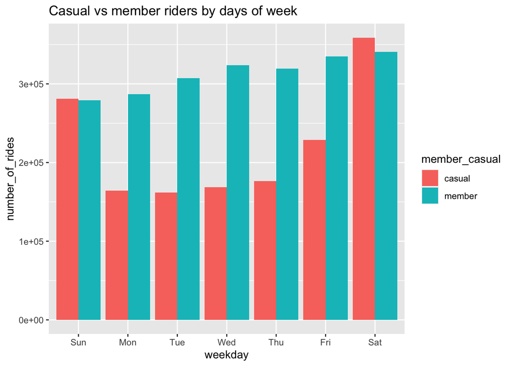

```r
all_trips_v2 %>%
  mutate(weekday = wday(started_at, label = TRUE)) %>%
  group_by(member_casual, weekday) %>%
  summarise(number_of_rides = n()
            ,average_duration = mean(ride_length)) %>%
  arrange(member_casual, weekday)  %>%
  ggplot(aes(x = weekday, y = number_of_rides, fill = member_casual)) +
  geom_col(position = "dodge") +
  labs(title = "Casual vs member riders by days of week")
```

The annual members clearly do more rides than casual riders for any weekday. But does not hold so for the weekends. Important takeaway here - While the surge in casual riders happen during the weekends, the annual members use the service more often during the weekdays.  
Next, let’s do the same but with mean duration of rides.

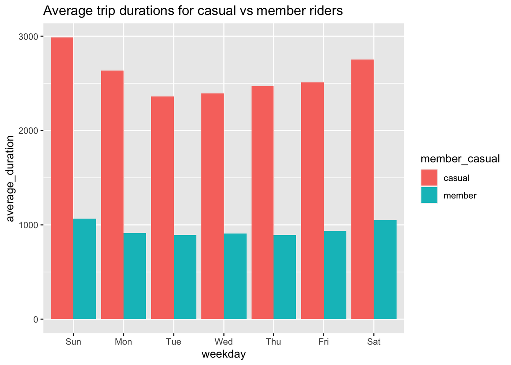

```r
# Let's create a visualization for average duration
all_trips_v2 %>%
  mutate(weekday = wday(started_at, label = TRUE)) %>%
  group_by(member_casual, weekday) %>%
  summarise(number_of_rides = n()
            ,average_duration = mean(ride_length)) %>%
  arrange(member_casual, weekday)  %>%
  ggplot(aes(x = weekday, y = average_duration, fill = member_casual)) +
  geom_col(position = "dodge") +
  labs(title = "Average trip durations for casual vs member riders")
```

Takeaway - The mean duration is significantly higher for the casual riders for any day of the week.  
How about the trend across months in a year? Let’s see that now.

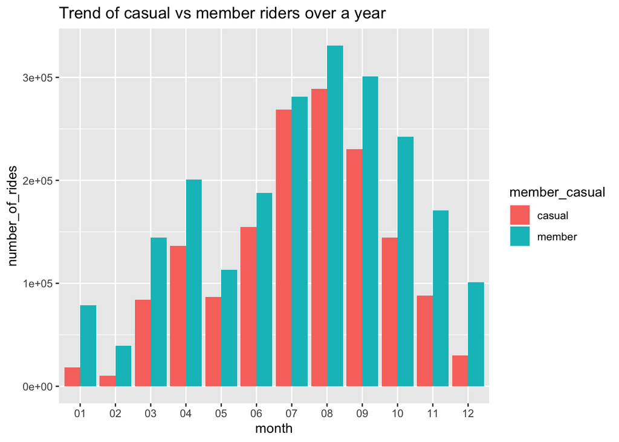

```r
all_trips_v2 %>%
  group_by(member_casual, month) %>%
  summarise(number_of_rides = n()
            ,average_duration = mean(ride_length)) %>%
  arrange(member_casual, month)  %>%
  ggplot(aes(x = month, y = number_of_rides, fill = member_casual)) +
  geom_col(position = "dodge") +
  labs(title = "Trend of casual vs member riders over a year")
```

Not much difference in the trends for the two groups. Close to a **normal** curve for both groups with peaks around **July-August**.

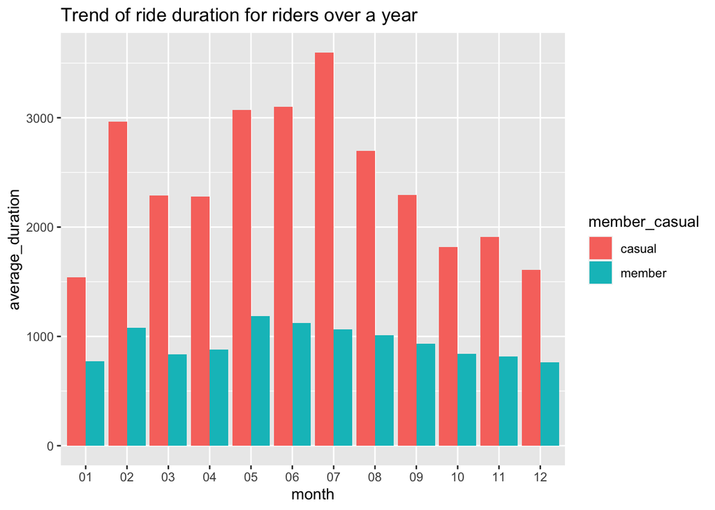

```r
all_trips_v2 %>%
  group_by(member_casual, month) %>%
  summarise(number_of_rides = n()
            ,average_duration = mean(ride_length)) %>%
  arrange(member_casual, month)  %>%
  ggplot(aes(x = month, y = average_duration, fill = member_casual)) +
  geom_col(position = "dodge") +
  labs(title = "Trend of ride duration for riders over a year")
```

Let’s now explore one more layer of granularity, the hours of a day. Let’s divide the analysis into weekdays and weekends.

### Weekdays

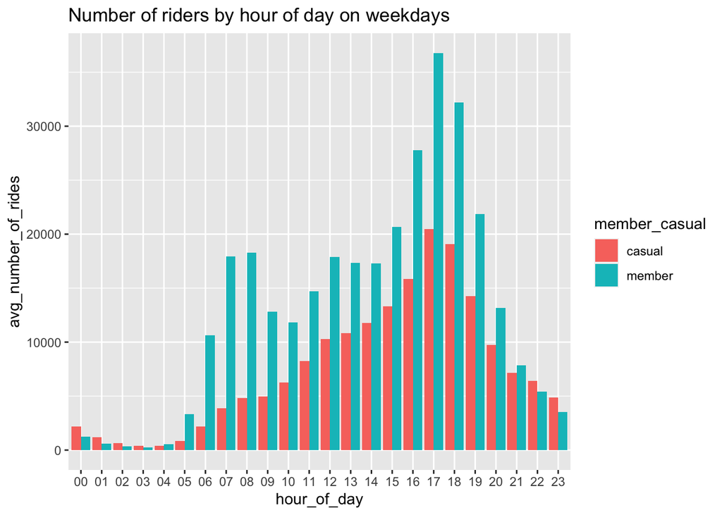

```r
# For weekdays ----
all_trips_v2 %>%
  filter(!day_of_week %in% c("Saturday", "Sunday")) %>%
  group_by(member_casual, hour_of_day) %>%
  summarise(avg_number_of_rides = n()/5
            ,average_duration = mean(ride_length)) %>%
  arrange(member_casual, hour_of_day)  %>%
  ggplot(aes(x = hour_of_day, y = avg_number_of_rides, fill = member_casual)) +
  geom_col(position = "dodge") +
  labs(title = "Number of riders by hour of day on weekdays")
```

Two peaks for annual members, one in the morning hours and the other in in the evening around 4-5pm. Casual riders have a lower outing on average with riders gradually peaking in the evening around 4-5pm.

### Weekends

[figure not shown]

```r
# For weekends-----
all_trips_v2 %>%
  filter(day_of_week %in% c("Saturday", "Sunday")) %>%
  group_by(member_casual, hour_of_day) %>%
  summarise(avg_number_of_rides = n()/2
            ,average_duration = mean(ride_length)) %>%
  arrange(member_casual, hour_of_day)  %>%
  ggplot(aes(x = hour_of_day, y = avg_number_of_rides, fill = member_casual)) +
  geom_col(position = "dodge") +
  labs(title = "Average ride duration by hour of dayon weekends")
```

The trend here is similar for both groups. There is a decent increase of the casual riders in weekends (~5000 - 10000 on average) and the number of annual members have also fallen down quite a bit from the weekdays and are definitely not leading anymore for a significant chunk of the day especially close to the peak.

*The aggregated data have been written to csv files earlier and can be used for further analysis.*